# Comparing Differential Expression Analysis

ALSF CCDL - Candace Savonen

*Purpose*: This notebook takes data processed by refine.bio and compares the differential expression results to a list of differential expressed genes.

You may obtain differential expression results from your own data or a collaborator’s data. It is good practice to validate your findings in another dataset that measures a similar tissue with a similar experimental design. You can use refine.bio datasets and the steps in this example to quickly check for agreement with your results. Ideally when comparing datasets’ differential expression results, both results have been obtained using the same exact pipeline.

Here we will compare differential expression results we’ve previously obtained to results from a refine.bio dataset with similar data.

In this notebook, we are looking for whether the results we found in the Northcott data are generalizable to [refine.bio dataset that also measures medulloblastoma subgroups](https://www.refine.bio/experiments/GSE37418/novel-mutations-target-distinct-subgroups-of-medulloblastoma). These data are originally from [Robinson et al, 2012. Nature.](https://www.ncbi.nlm.nih.gov/pubmed/22722829) but were downloaded from refine.bio. This dataset was chosen because, like Northcott et al data, it also has subgroup medulloblastoma information that we will use in this notebook for differential expression testing.

The output from this notebook are two Venn diagrams showing the gene list overlap between these two datasets (one for up-regulated gene list, and the other for down-regulated). In both these datasets, we consider genes that are significantly higher in `SHH` subgroup samples than in `NonSHH` samples to be `up-regulated`.

There are a number of ways to compare differential expression results, but this notebook’s example takes the simplest approach of looking at overlap of gene lists. This is partially so that this notebook’s approach can be applied to any differential expression output, provided that the output meets certain criteria listed below.

### What you will need to apply this dataset to your own results:

At the bare minimum, you will need two gene lists, one for up-regulated and another for down-regulated genes.

Ideally you will have table of differential expression results that will have:

1. A gene or probe identifier
2. The direction of the expression differences (often indicated by fold-change)
3. p-values that are corrected for multiple testing (e.g., FDR)

This example shows one method of summarizing and converting Affymetrix probe IDs to Ensembl gene IDs, but depending on what type of gene identifiers and results you have, you may need to do a few conversion steps.

## 1) Set up

```r
if (!("limma" %in% installed.packages())) {
  # Install limma
  BiocManager::install("limma", update = FALSE)
}
if (!("VennDiagram" %in% installed.packages())) {
  # Install VennDiagram
  BiocManager::install("VennDiagram", update = FALSE)
}
```

Attach the `limma` library:

```r
# Magrittr pipe
`%>%` <- dplyr::`%>%`

# Attach library
library(limma)
```

Set up output directories if they haven’t been set up yet.

```r
# Define the file path to the results directory
results_dir <- "results"  # Replace with path to desired output results directory

# Make a results directory if it isn't created yet
if (!dir.exists(results_dir)) {
  dir.create(results_dir)
}

# Define the file path to the plots directory
plots_dir <- "plots"  # Replace with path to desired output plots directory

# Make a plots directory if it isn't created yet
if (!dir.exists(plots_dir)) {
  dir.create(plots_dir)
}

# Define the file path to the data directory
data_dir <- "data"  # Replace with path to data directory
```

## 2) Import differential expression results from Northcott dataset

Import the `limma` results obtained for the author-processed data for Northcott et al, 2012. If you’d like to see how we generated these results with `limma`, see `author_processed_DE` in this folder. Note that these differential expression results come with Affymetrix probe IDs (our source of gene identifier), `logFC`(our source of direction), and `adj.P.Val` (our source of significance level).

```r
# Load in the summary statistics from limma run
author.full.results <- readr::read_tsv(file.path(results_dir,
                                                 "GSE37382_limma_results.tsv" # Replace with name of your own differential expression results file you've generated that you'd like to compare to refinebio data
                                                 ))
```

## 3) Convert the differentially expressed gene identifiers to Ensembl gene IDs

In refine.bio all IDs are converted to Ensembl gene IDs in the harmonization pipeline. Here we need to convert our Affymetrix transcript cluster IDs into Ensembl gene IDs so we can compare our datasets. If you are using this notebook for your own data, and need more information on how to perform ID conversion, you can look at `ensembl_id_convert` in this repository for more information. You can also use the [ID conversion repository prepared by the CCDL.](https://github.com/AlexsLemonade/identifier-refinery) The pre-made ID conversion key files themselves for refine.bio supported microarray platforms can be downloaded from [Zenodo](https://zenodo.org/record/1322711#.XLdJb-tKiXE).

```r
# Unzip hugene11st ID conversion file obtained from identifier refinery
id.conversion.file <- file.path(data_dir, "hugene11st.tsv")
if (!file.exists(id.conversion.file)) {
  unzip(paste0(id.conversion.file, ".zip"), exdir = data_dir)
}

# Read in the probe conversion info - this step may take some time
probe.conversion <- readr::read_tsv(id.conversion.file,
                                    progress = FALSE) %>%
  dplyr::select("PROBEID", "ENSEMBL")
# Add annotation to imported author limma results
author.full.results <- author.full.results %>%
  # You may need to replace "affy_probe_ids" with the name of the column that        # contains the probe IDs in your data
  dplyr::inner_join(probe.conversion, by = c("affy_probe_ids" = "PROBEID")) %>%
  dplyr::mutate("ENSEMBL" = as.factor(ENSEMBL)) %>%
  # Determine direction of fold change.
  # Note up-directed genes will be TRUE, down-genes will be FALSE
  # You may need to replace <logFC> with the name of the column that contains the    # log fold change values in your data
  dplyr::mutate('direction' = logFC > 0) %>%
  # This is to make sure we don't get repeat probes
  dplyr::distinct()

# Take a look at the preview of this results table
author.full.results
```

| affy_probe_ids | logFC | AveExpr | t | P.Value | adj.P.Val | B | ENSEMBL | direction |
| --- | --- | --- | --- | --- | --- | --- | --- | --- |
| 7977653 | 1.9453896 | 3.930772 | 60.55173 | 2.325417e-165 | 7.742943e-161 | 367.5885 | ENSG00000200102 | TRUE |
| 8096461 | 6.9560935 | 5.675544 | 53.96712 | 3.494633e-152 | 3.878693e-148 | 337.4996 | ENSG00000172238 | TRUE |
| 8085118 | 1.7806963 | 4.209719 | 48.33235 | 8.201168e-140 | 5.461486e-136 | 309.1941 | ENSG00000241227 | TRUE |
| 8121209 | 3.8052036 | 5.989649 | 45.79656 | 7.172058e-134 | 3.980134e-130 | 295.5819 | ENSG00000184486 | TRUE |
| 7950032 | 1.4630719 | 4.874035 | 45.70973 | 1.157561e-133 | 5.506188e-130 | 295.1054 | ENSG00000075388 | TRUE |
| 8063723 | 1.5562016 | 4.166982 | 45.36677 | 7.719475e-133 | 3.212942e-129 | 293.2168 | ENSG00000124203 | TRUE |
| 8075553 | 1.5140523 | 3.773158 | 45.27029 | 1.318974e-132 | 4.879765e-129 | 292.6835 | ENSG00000240647 | TRUE |
| 8132845 | 1.6368074 | 3.797860 | 44.53578 | 8.015071e-131 | 2.668778e-127 | 288.5948 | ENSG00000199629 | TRUE |
| 8099144 | 2.6635646 | 4.289544 | 44.45021 | 1.297562e-130 | 3.927721e-127 | 288.1151 | ENSG00000173040 | TRUE |
| 8104022 | 5.8757290 | 6.154737 | 43.58582 | 1.752572e-128 | 4.862950e-125 | 283.2301 | ENSG00000154553 | TRUE |

[output cut: 990 more lines]

### Summarize probe-level data into gene-level data

```r
# Summarize the direction of significant probes for each gene
direction.summary <- author.full.results %>%
  # Keep only significant at 0.05 probes -- you may need to replace <adj.P.Val>      # with the name of the column that contains the adjusted P values for your data
  dplyr::filter(adj.P.Val < 0.05) %>%
  # Group probes by their associated
  dplyr::group_by(ENSEMBL) %>%
  dplyr::summarize('up' = sum(direction),
                   'down' = sum(!direction))

# Print out this dataset
direction.summary
```

| ENSEMBL | up | down |
| --- | --- | --- |
| ENSG00000000003 | 1 | 0 |
| ENSG00000000005 | 1 | 0 |
| ENSG00000000419 | 1 | 0 |
| ENSG00000000457 | 1 | 0 |
| ENSG00000000460 | 1 | 0 |
| ENSG00000000938 | 1 | 0 |
| ENSG00000000971 | 2 | 0 |
| ENSG00000001036 | 1 | 0 |
| ENSG00000001084 | 1 | 0 |
| ENSG00000001167 | 1 | 0 |

[output cut: 990 more lines]

Now we have a count of how many probes are significant in each direction. We will summarize these gene level probe summaries into two gene lists. Some genes may have probesets that are both up and down. For this analysis, we will only keep genes in the significance lists if all the probesets are in the same direction.

```r
# Create an up-regulated genes list
author.up.genes <- direction.summary %>%
  # Upregulated genes are only those that have no significant downregulated
  # probesets
  dplyr::filter(down == 0) %>%
  dplyr::pull(ENSEMBL) %>%
  as.character()

author.down.genes <- direction.summary %>%
  # Downregulated genes are only those that have no significant upregulated
  # probesets
  dplyr::filter(up == 0) %>%
  dplyr::pull(ENSEMBL) %>%
  as.character()
```

## 4) Import and set up refine.bio processed data.

Data downloaded from refine.bio are in tab separated values (TSV) files and include a metadata in a separate TSV file. This data set was obtained from [refine.bio](https://www.refine.bio/).

```r
# Put name of data file
refine.bio.data.filename <- file.path(data_dir,
                                      "GSE37418.tsv" # Replace with your desired refine.bio processed data file
                                      )

# Read in data tsv file
refine.bio.df <- readr::read_tsv(refine.bio.data.filename, progress = FALSE) %>%
  # Make the gene column the rownames so the gene names are out of the way for calculations
  tibble::column_to_rownames('Gene')
```

Set up the metadata for this set.

```r
# Metadata file name
metadata.filename <- file.path(data_dir,
                               "metadata_GSE37418.tsv" # Replace with name of metadata file relevant to your refine.bio processed data file
                               )

# Read in metadata tsv file
metadata <- readr::read_tsv(metadata.filename) %>%
  # Get rid of columns that have only NAs
  dplyr::select(-which(apply(is.na(.), 2, all)))
# Print out metadata so we can get an idea of what we have
metadata
```

| refinebio_accession_code | refinebio_organism | refinebio_platform | refinebio_sex | refinebio_source_database | refinebio_title | Sex | age | channel_count | contact_address | contact_city | contact_country | contact_department | contact_email | contact_institute | contact_name | contact_phone | contact_state | contact_zip/postal_code | data_processing | data_row_count | description | ethnic | extract_protocol_ch1 | geo_accession | hyb_protocol | label_ch1 | label_protocol_ch1 | last_update_date | m stage | … |
| --- | --- | --- | --- | --- | --- | --- | --- | --- | --- | --- | --- | --- | --- | --- | --- | --- | --- | --- | --- | --- | --- | --- | --- | --- | --- | --- | --- | --- | --- | --- |
| GSM918612 | HOMO_SAPIENS | Affymetrix Human Genome U133 Plus 2.0 Array (hgu133plus2) | male | GEO | SJMB087 | Male | 3yrs 2mos | 1 | 332 N. Lauderdale St. | Memphis | USA | Computational Biology | david.finkelstein@stjude.org | St Jude Children's Research Hospital | David,,Finkelstein | 9014953931 | TN | 38105 | The data were analyzed with Microarray Suite version 5.0 (MAS 5.0) using Affymetrix default analysis settings and global scaling as normalization method. The trimmed mean target intensity of each arra… | 54675 | primary tumor | Hispanic | Isolation was performed using RNA STAT-60, according to the manufacturer's instructions. Briefly, tissue samples were homogenized in the STAT-60 using teflon homogenizers. Chloroform was added and the… | GSM918612 | Following fragmentation, 15 ug of cRNA were hybridized for 16 hr at 45C on GeneChip Human U133 v2.0. GeneChips were washed and stained in the Affymetrix Fluidics Station 450. | Biotin | Biotinylated cRNA were prepared according to the standard Affymetrix Two-Cycle protocol from 100 ng of total RNA (Expression Analysis Technical Manual, 2005-2006, Affymetrix). | Jul 06 2012 | MB-AN | … |
| GSM918644 | HOMO_SAPIENS | Affymetrix Human Genome U133 Plus 2.0 Array (hgu133plus2) | female | GEO | SJMB131 | Female | 9yrs 1mos | 1 | 332 N. Lauderdale St. | Memphis | USA | Computational Biology | david.finkelstein@stjude.org | St Jude Children's Research Hospital | David,,Finkelstein | 9014953931 | TN | 38105 | The data were analyzed with Microarray Suite version 5.0 (MAS 5.0) using Affymetrix default analysis settings and global scaling as normalization method. The trimmed mean target intensity of each arra… | 54675 | primary tumor | Asian | Isolation was performed using RNA STAT-60, according to the manufacturer's instructions. Briefly, tissue samples were homogenized in the STAT-60 using teflon homogenizers. Chloroform was added and the… | GSM918644 | Following fragmentation, 15 ug of cRNA were hybridized for 16 hr at 45C on GeneChip Human U133 v2.0. GeneChips were washed and stained in the Affymetrix Fluidics Station 450. | Biotin | Biotinylated cRNA were prepared according to the standard Affymetrix Two-Cycle protocol from 100 ng of total RNA (Expression Analysis Technical Manual, 2005-2006, Affymetrix). | Jul 06 2012 | MB-Myo | … |
| GSM918589 | HOMO_SAPIENS | Affymetrix Human Genome U133 Plus 2.0 Array (hgu133plus2) | male | GEO | SJMB050 | Male | 5yrs 2mos | 1 | 332 N. Lauderdale St. | Memphis | USA | Computational Biology | david.finkelstein@stjude.org | St Jude Children's Research Hospital | David,,Finkelstein | 9014953931 | TN | 38105 | The data were analyzed with Microarray Suite version 5.0 (MAS 5.0) using Affymetrix default analysis settings and global scaling as normalization method. The trimmed mean target intensity of each arra… | 54675 | primary tumor | Hispanic | Isolation was performed using RNA STAT-60, according to the manufacturer's instructions. Briefly, tissue samples were homogenized in the STAT-60 using teflon homogenizers. Chloroform was added and the… | GSM918589 | Following fragmentation, 15 ug of cRNA were hybridized for 16 hr at 45C on GeneChip Human U133 v2.0. GeneChips were washed and stained in the Affymetrix Fluidics Station 450. | Biotin | Biotinylated cRNA were prepared according to the standard Affymetrix Two-Cycle protocol from 100 ng of total RNA (Expression Analysis Technical Manual, 2005-2006, Affymetrix). | Jul 06 2012 | MB-CL | … |
| GSM918619 | HOMO_SAPIENS | Affymetrix Human Genome U133 Plus 2.0 Array (hgu133plus2) | male | GEO | SJMB033 | Male | 16yrs 8mos | 1 | 332 N. Lauderdale St. | Memphis | USA | Computational Biology | david.finkelstein@stjude.org | St Jude Children's Research Hospital | David,,Finkelstein | 9014953931 | TN | 38105 | The data were analyzed with Microarray Suite version 5.0 (MAS 5.0) using Affymetrix default analysis settings and global scaling as normalization method. The trimmed mean target intensity of each arra… | 54675 | primary tumor | White | Isolation was performed using RNA STAT-60, according to the manufacturer's instructions. Briefly, tissue samples were homogenized in the STAT-60 using teflon homogenizers. Chloroform was added and the… | GSM918619 | Following fragmentation, 15 ug of cRNA were hybridized for 16 hr at 45C on GeneChip Human U133 v2.0. GeneChips were washed and stained in the Affymetrix Fluidics Station 450. | Biotin | Biotinylated cRNA were prepared according to the standard Affymetrix Two-Cycle protocol from 100 ng of total RNA (Expression Analysis Technical Manual, 2005-2006, Affymetrix). | Jul 06 2012 | MB-CL | … |
| GSM918634 | HOMO_SAPIENS | Affymetrix Human Genome U133 Plus 2.0 Array (hgu133plus2) | male | GEO | SJMB039 | Male | 8yrs 2mos | 1 | 332 N. Lauderdale St. | Memphis | USA | Computational Biology | david.finkelstein@stjude.org | St Jude Children's Research Hospital | David,,Finkelstein | 9014953931 | TN | 38105 | The data were analyzed with Microarray Suite version 5.0 (MAS 5.0) using Affymetrix default analysis settings and global scaling as normalization method. The trimmed mean target intensity of each arra… | 54675 | primary tumor | White | Isolation was performed using RNA STAT-60, according to the manufacturer's instructions. Briefly, tissue samples were homogenized in the STAT-60 using teflon homogenizers. Chloroform was added and the… | GSM918634 | Following fragmentation, 15 ug of cRNA were hybridized for 16 hr at 45C on GeneChip Human U133 v2.0. GeneChips were washed and stained in the Affymetrix Fluidics Station 450. | Biotin | Biotinylated cRNA were prepared according to the standard Affymetrix Two-Cycle protocol from 100 ng of total RNA (Expression Analysis Technical Manual, 2005-2006, Affymetrix). | Jul 06 2012 | MB-CL | … |
| GSM918611 | HOMO_SAPIENS | Affymetrix Human Genome U133 Plus 2.0 Array (hgu133plus2) | male | GEO | SJMB030 | Male | 8yrs 7mos | 1 | 332 N. Lauderdale St. | Memphis | USA | Computational Biology | david.finkelstein@stjude.org | St Jude Children's Research Hospital | David,,Finkelstein | 9014953931 | TN | 38105 | The data were analyzed with Microarray Suite version 5.0 (MAS 5.0) using Affymetrix default analysis settings and global scaling as normalization method. The trimmed mean target intensity of each arra… | 54675 | primary tumor | White | Isolation was performed using RNA STAT-60, according to the manufacturer's instructions. Briefly, tissue samples were homogenized in the STAT-60 using teflon homogenizers. Chloroform was added and the… | GSM918611 | Following fragmentation, 15 ug of cRNA were hybridized for 16 hr at 45C on GeneChip Human U133 v2.0. GeneChips were washed and stained in the Affymetrix Fluidics Station 450. | Biotin | Biotinylated cRNA were prepared according to the standard Affymetrix Two-Cycle protocol from 100 ng of total RNA (Expression Analysis Technical Manual, 2005-2006, Affymetrix). | Jul 06 2012 | MB-CL | … |
| GSM918590 | HOMO_SAPIENS | Affymetrix Human Genome U133 Plus 2.0 Array (hgu133plus2) | male | GEO | SJMB020 | Male | 8yrs 9mos | 1 | 332 N. Lauderdale St. | Memphis | USA | Computational Biology | david.finkelstein@stjude.org | St Jude Children's Research Hospital | David,,Finkelstein | 9014953931 | TN | 38105 | The data were analyzed with Microarray Suite version 5.0 (MAS 5.0) using Affymetrix default analysis settings and global scaling as normalization method. The trimmed mean target intensity of each arra… | 54675 | primary tumor | Hispanic | Isolation was performed using RNA STAT-60, according to the manufacturer's instructions. Briefly, tissue samples were homogenized in the STAT-60 using teflon homogenizers. Chloroform was added and the… | GSM918590 | Following fragmentation, 15 ug of cRNA were hybridized for 16 hr at 45C on GeneChip Human U133 v2.0. GeneChips were washed and stained in the Affymetrix Fluidics Station 450. | Biotin | Biotinylated cRNA were prepared according to the standard Affymetrix Two-Cycle protocol from 100 ng of total RNA (Expression Analysis Technical Manual, 2005-2006, Affymetrix). | Jul 06 2012 | MB-AN | … |
| GSM918628 | HOMO_SAPIENS | Affymetrix Human Genome U133 Plus 2.0 Array (hgu133plus2) | male | GEO | SJMB118 | Male | 8yrs 4mos | 1 | 332 N. Lauderdale St. | Memphis | USA | Computational Biology | david.finkelstein@stjude.org | St Jude Children's Research Hospital | David,,Finkelstein | 9014953931 | TN | 38105 | The data were analyzed with Microarray Suite version 5.0 (MAS 5.0) using Affymetrix default analysis settings and global scaling as normalization method. The trimmed mean target intensity of each arra… | 54675 | primary tumor | Black | Isolation was performed using RNA STAT-60, according to the manufacturer's instructions. Briefly, tissue samples were homogenized in the STAT-60 using teflon homogenizers. Chloroform was added and the… | GSM918628 | Following fragmentation, 15 ug of cRNA were hybridized for 16 hr at 45C on GeneChip Human U133 v2.0. GeneChips were washed and stained in the Affymetrix Fluidics Station 450. | Biotin | Biotinylated cRNA were prepared according to the standard Affymetrix Two-Cycle protocol from 100 ng of total RNA (Expression Analysis Technical Manual, 2005-2006, Affymetrix). | Jul 06 2012 | MB-DN | … |
| GSM918585 | HOMO_SAPIENS | Affymetrix Human Genome U133 Plus 2.0 Array (hgu133plus2) | female | GEO | SJMB045 | Female | 9yrs 0mos | 1 | 332 N. Lauderdale St. | Memphis | USA | Computational Biology | david.finkelstein@stjude.org | St Jude Children's Research Hospital | David,,Finkelstein | 9014953931 | TN | 38105 | The data were analyzed with Microarray Suite version 5.0 (MAS 5.0) using Affymetrix default analysis settings and global scaling as normalization method. The trimmed mean target intensity of each arra… | 54675 | primary tumor | White | Isolation was performed using RNA STAT-60, according to the manufacturer's instructions. Briefly, tissue samples were homogenized in the STAT-60 using teflon homogenizers. Chloroform was added and the… | GSM918585 | Following fragmentation, 15 ug of cRNA were hybridized for 16 hr at 45C on GeneChip Human U133 v2.0. GeneChips were washed and stained in the Affymetrix Fluidics Station 450. | Biotin | Biotinylated cRNA were prepared according to the standard Affymetrix Two-Cycle protocol from 100 ng of total RNA (Expression Analysis Technical Manual, 2005-2006, Affymetrix). | Jul 06 2012 | MB-CL | … |
| GSM918583 | HOMO_SAPIENS | Affymetrix Human Genome U133 Plus 2.0 Array (hgu133plus2) | female | GEO | SJMB015 | Female | 8yrs 1mos | 1 | 332 N. Lauderdale St. | Memphis | USA | Computational Biology | david.finkelstein@stjude.org | St Jude Children's Research Hospital | David,,Finkelstein | 9014953931 | TN | 38105 | The data were analyzed with Microarray Suite version 5.0 (MAS 5.0) using Affymetrix default analysis settings and global scaling as normalization method. The trimmed mean target intensity of each arra… | 54675 | primary tumor | White | Isolation was performed using RNA STAT-60, according to the manufacturer's instructions. Briefly, tissue samples were homogenized in the STAT-60 using teflon homogenizers. Chloroform was added and the… | GSM918583 | Following fragmentation, 15 ug of cRNA were hybridized for 16 hr at 45C on GeneChip Human U133 v2.0. GeneChips were washed and stained in the Affymetrix Fluidics Station 450. | Biotin | Biotinylated cRNA were prepared according to the standard Affymetrix Two-Cycle protocol from 100 ng of total RNA (Expression Analysis Technical Manual, 2005-2006, Affymetrix). | Jul 06 2012 | MB-CL | … |

[output cut: 61 more lines]

Let’s reformat our variable `subgroup` that we will be using for testing. To make the comparisons more reasonably similar, we will get rid of samples that *aren’t* SHH, Group3, or Group4.

```r
# Reformat subgroup names to make Group 3 and 4 into "NonSHH"
metadata$subgroup <- gsub("G3|G4", "NonSHH", metadata$subgroup)

# Check out subgroup summary
summary(as.factor(metadata$subgroup))
```

```
     NonSHH         SHH SHH OUTLIER           U         WNT
         51          10           1           2           7
```

To make this dataset more comparable to our imported dataset (which only has SHH, Group3, or Group4), we will get rid of samples that *aren’t* in one of these classifications.

```r
# Only keep samples that are SHH or Non-SHH (which is now both Group3 and Group4)
metadata <- metadata %>%
  dplyr::filter(subgroup %in% c("SHH", "NonSHH"))
```

Make refine.bio metadata and data are same samples, in the same order.

```r
# Reorder/filter data to match metadata
refine.bio.df <- refine.bio.df[, match(metadata$refinebio_accession_code,
                                       colnames(refine.bio.df))]

# Check if they are the same:
all.equal(colnames(refine.bio.df), metadata$refinebio_accession_code)
```

```
[1] TRUE
```

## 5) Perform differential expression analysis on refine.bio data

Here we are using the same model and set up as we used for the Northcott data in `author_processed_DE`. `limma` needs a numeric design matrix to signify which samples belong to which groups you are testing. Note that we are using the medulloblastoma subgroups as our variable for testing. This is the same type of variable we used for our imported author processed dataset (See `author_processed_DE`).

```r
# Make subgroup a factor
metadata$subgroup <- as.factor(metadata$subgroup)

# Create the design matrix
des.mat <- model.matrix(~ metadata$subgroup)

# Make the column name more informative
colnames(des.mat)[2] <- paste0(levels(metadata$subgroup), collapse = "vs")
```

## 6) Apply linear model

Here we will fit our data to a model using our design matrix and then apply empirical Bayes for smoothing. This same kind of model was applied to the Northcott data in `author_processed_DE`).

```r
# Initial fit
fit <- lmFit(refine.bio.df, design = des.mat)

# eBayes for smoothing
fit <- eBayes(fit)
```

Obtain summary statistics and apply Benjamini-Hochberg multiple testing correction to the p-values.

```r
# Apply multiple testing correction and obtain stats
refine.bio.results <- topTable(fit, number = nrow(refine.bio.df)) %>%
  tibble::rownames_to_column("ENSEMBL")
```

```
Removing intercept from test coefficients
```

```r
# Print out stats
refine.bio.results
```

| ENSEMBL | logFC | AveExpr | t | P.Value | adj.P.Val | B |
| --- | --- | --- | --- | --- | --- | --- |
| ENSG00000092421 | 16.2846986 | 4.579825542 | 18.424880 | 2.435589e-26 | 3.885062e-22 | 49.312265 |
| ENSG00000184486 | 6.5642421 | 1.473065290 | 18.257737 | 3.874214e-26 | 3.885062e-22 | 48.867118 |
| ENSG00000124479 | 12.6065179 | 2.488712534 | 18.029380 | 7.339907e-26 | 4.467922e-22 | 48.253736 |
| ENSG00000144857 | 12.6897880 | 3.406281130 | 17.960463 | 8.910894e-26 | 4.467922e-22 | 48.067430 |
| ENSG00000196411 | 1.2244634 | 0.742209436 | 17.565773 | 2.733126e-25 | 1.096311e-21 | 46.989703 |
| ENSG00000134376 | 3.5106101 | 0.678396645 | 16.886180 | 1.960765e-24 | 6.554183e-21 | 45.090362 |
| ENSG00000005471 | 3.0340221 | 0.478528207 | 16.474059 | 6.645843e-24 | 1.904129e-20 | 43.911030 |
| ENSG00000154553 | 12.5163149 | 2.275798216 | 16.395519 | 8.405307e-24 | 2.107210e-20 | 43.683880 |
| ENSG00000135596 | 24.8685401 | 6.132044345 | 16.322794 | 1.045405e-23 | 2.329627e-20 | 43.472859 |
| ENSG00000152894 | 47.4283820 | 14.593743685 | 16.277609 | 1.197510e-23 | 2.401726e-20 | 43.341413 |

[output cut: 990 more lines]

Write these results to an output file.

```r
readr::write_tsv(refine.bio.results, file.path(results_dir,
                                               "GSE37418_limma_results.tsv" # Replace with relevant output file name
                                               ))
```

### Create up/down-regulated gene lists for refine.bio results

Here we are using an adjusted p-value cutoff of `0.05`. We are not applying a magnitude cutoff for `logFC` but using logFC just to summarize direction of regulation. Depending on your own data, you may want to adjust these. For instance, you may only be interested in genes with high fold change.

```r
# Create up-regulated gene list for refinebio
refine.bio.up.genes <- refine.bio.results %>%
  # Apply cutoffs for p values and fold change direction to be up
  dplyr::filter(adj.P.Val < 0.05, logFC > 0) %>%
  # Reduce this to a gene ID vector list
  dplyr::pull(ENSEMBL) %>%
  as.character()

# Create down-regulated gene list for refinebio
refine.bio.down.genes <- refine.bio.results %>%
  dplyr::filter(adj.P.Val < 0.05, logFC < 0) %>%
  dplyr::pull(ENSEMBL) %>%
  as.character()
```

## 7) Double check results directions with a boxplot

Let’s pick a couple genes from the Robinson and Northcott results to double check our output. We previously did this same test for the Northcott data in the in `author_processed_DE`.

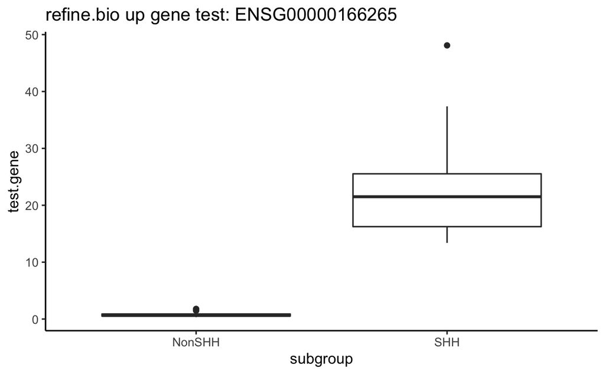

```r
# Extract a gene's data from the original refine.bio data.frame
test.gene <- refine.bio.df %>%
  tibble::rownames_to_column("genes") %>%
  dplyr::filter(genes == refine.bio.up.genes[12]) %>%
  dplyr::select(-genes) %>%
  t()

# Make a dataframe with the group information
box.plot <- data.frame(test.gene, subgroup = metadata$subgroup) %>%

# Use ggplot2 to make a boxplot from this info
ggplot2::ggplot(., ggplot2::aes(x = subgroup, y = test.gene)) +
  ggplot2::geom_boxplot() +
  ggplot2::theme_classic() +
  ggplot2::ggtitle(paste("refine.bio up gene test:", refine.bio.up.genes[12]))

# Print the plot here
box.plot
```

## 8) Set up exploration of overlap of the datasets differential expression

Here we will set up the data for making two Venn diagrams: one for overlap between the datasets for up-regulated genes, the other for down-regulated genes. Determine overlap in up-regulated genes between datasets.

```r
# Make into named list
up.genes <- list('refine.bio' = refine.bio.up.genes,
                 'author' = author.up.genes)

# Make into named list
down.genes <- list('refine.bio' = refine.bio.down.genes,
                   'author' = author.down.genes)
```

Determine overlap in gene sets between datasets.

```r
# Calculate overlap of these gene lists:
up.overlap <- VennDiagram::calculate.overlap(up.genes)

# Calculate overlap of these gene lists:
down.overlap <- VennDiagram::calculate.overlap(down.genes)
```

## 9) Make Venn diagrams

### Overlap between up-regulated genes

Make Venn diagram of up-regulation results and save to png.

```r
# Make filename to save plot as
up.plot.file <- file.path(plots_dir,
                          "up-regulated_venn_northcott_vs_robinson.png")

# Make the Venn diagram
grid::grid.newpage();
up.venn.plot <- VennDiagram::draw.pairwise.venn(
  area1 = length(up.genes[[1]]),
  area2 = length(up.genes[[2]]),
  cross.area = length(up.overlap[[3]]),
  category = c("refine.bio", "author"),
  fill = c("blue", "yellow"),
  cex = 2,
  cat.cex = 1.5,
  cat.dist = c(-0.12, -0.13),
  cat.pos = c(170, 65),
  ext.pos = 0,
  ext.dist = -0.01,
  ext.length = .8,
  ext.line.lwd = 2,
  ext.line.lty = "dashed");
```

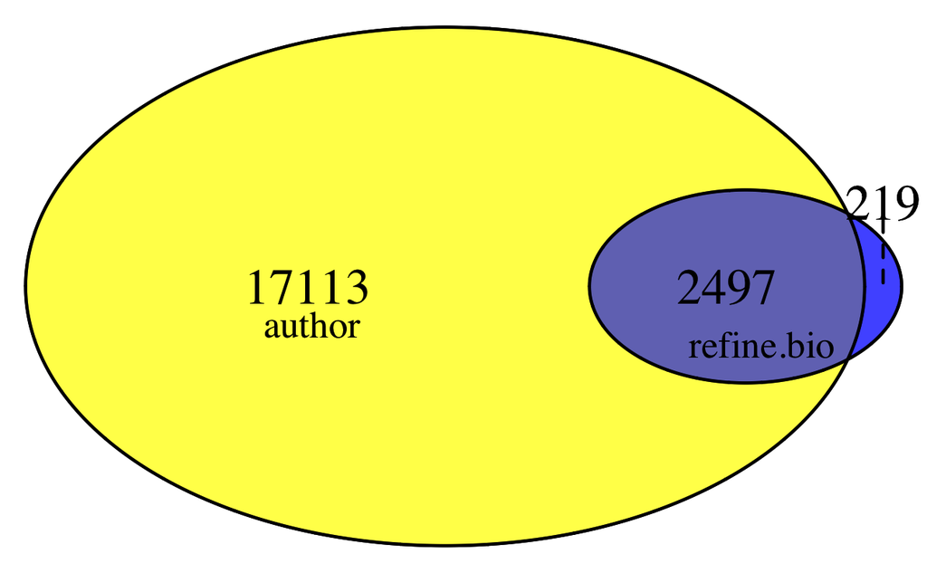

```r
grid::grid.draw(up.venn.plot) # Draw plot
```

Save up-regulated genes Venn to a png.

```r
png(up.plot.file);
grid::grid.draw(up.venn.plot);
dev.off()
```

### Overlap between down-regulated genes

Repeat the process for down-regulation results.

```r
# Make filename to save plot as
down.plot.file <- file.path(plots_dir,
                            "down-regulated_venn_northcott_vs_robinson.png")

# Make the Venn diagram
grid::grid.newpage();
down.venn.plot <- VennDiagram::draw.pairwise.venn(
  area1 = length(down.genes[[1]]),
  area2 = length(down.genes[[2]]),
  cross.area = length(down.overlap[[3]]),
  title = "Down-regulated Genes",
  category = c("refine.bio", "author"),
  fill = c("blue", "yellow"),
  cex = 2,
  cat.cex = 1.5,
  cat.dist = c(-0.11, -0.035),
  cat.pos = c(240, 120),
  ext.pos = 0,
  ext.dist = -0.01,
  ext.length = .8,
  ext.line.lwd = 2,
  ext.line.lty = "dashed");
```

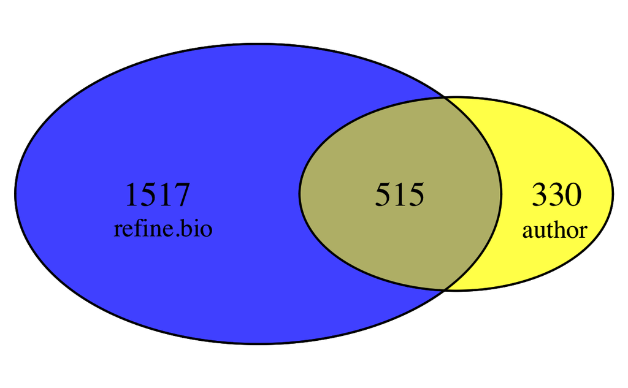

```r
grid::grid.draw(down.venn.plot) # Draw plot
```

Save down-regulated genes Venn to a png.

```r
png(down.plot.file);
grid::grid.draw(down.venn.plot);
dev.off()
```

## 10) Write overlapped gene list to tsv

Using `calculate.overlap`, we obtained a list of genes that were changed in both datasets. If we want to extract the list of genes that are in both dataset, that is the third vector in the output object so we use `[[3]]`.

```r
# Write the up-regulated gene overlap lists to tsv file
data.frame(up.overlap[[3]]) %>%
  readr::write_tsv(file.path(results_dir, "up-regulated_overlap_gene_list.tsv"))

# Do the same but for the down-regulated gene overlap list
data.frame(down.overlap[[3]]) %>%
  readr::write_tsv(file.path(results_dir, "down-regulated_overlap_gene_list.tsv"))
```